# Assignment 3: Data Visualization (incarceration)

Mat Medina

3/1/2022

### Introduction

I’m curious to see, compare, and analyze the Asian american pacific islander population in jail with the White population in jail.

### Summary

After going through the data, it seems like compared to the average amount of Asian american pacific islander population across all county jails, which is 4602.6769672, it doesn’t even come close to the White population across all county jails, which is 4.1094818^{4}. Also to keep note, the county jail with the highest White and Asian population respectively are Los Angeles County, and Los Angeles County While the county jail(s) with the lowest white and Asian population respectively are Wade Hampton Census Area and Wade Hampton Census Area, Wallace County, Petroleum County, Arthur County, Banner County, Blaine County, Garden County, McPherson County, Harding County, Slope County, Sully County, Kent County, Loving County, Motley County.

### Trends over Time

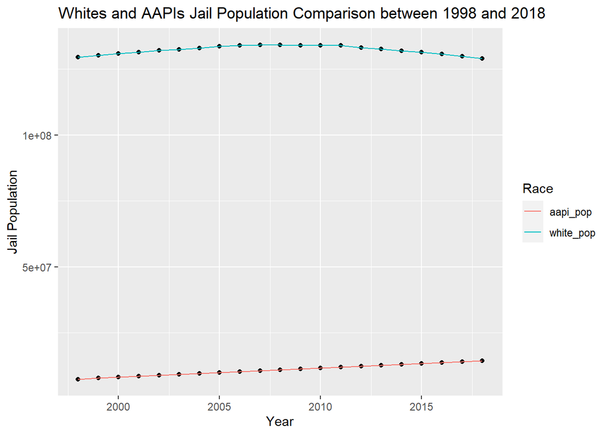

This trend shows the overall White and AAPI population across all county jails from the year 1998 to 2018, as noted that the White population vastly outnumbers the AAPI across the board, though the white population in recent trend is going down while AAPI is only progressively going up albeit slightly.

### Variable Comparison

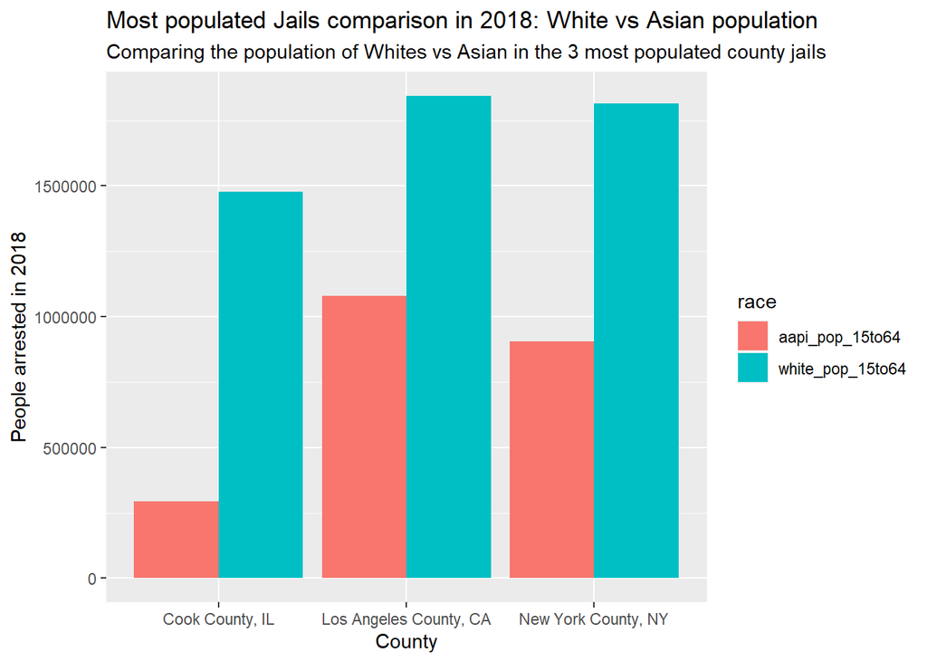

This chart shows the top three counties with the most amounts of occupants showing how much Asian and White Jailants are in each one in comparison to each other. In all cases the White population exceeds the Asian population.

### Map

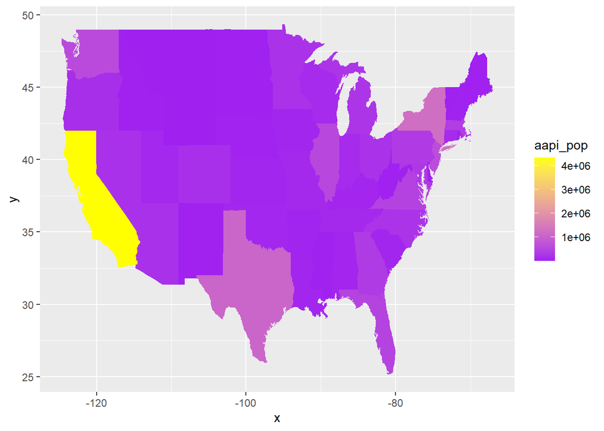

This map shows a each of the states color coordinated to show a gradient change from purple to yellow of AAPI Jail population, interestingly compared to all other states California vastly outnumbers every other state.